# nf-core spring survey 2025

## Introduction

This notebook processes the results of the nf-core community general survey from February/March 2025.

## Preparation

Load relevant libraries

```r
library(tidyverse)
library(janitor)
library(patchwork)
```

Load relevant data files, and make the column names easier to parse programatically.

```r
## Raw responses
data_responses_raw <- read_csv("data/nf-core_community_survey_-_Feb_2025_-_nf-core_community_survey_2025.csv") |> clean_names()

## Free text response columns plus columns containing manually tagged 'keyword' by @jfy133
data_responses_tagged <- read_csv(
  "data/nf-core_community_survey_-_Feb_2025_-_2025-03-16-freeze-annotated_(JFY).csv"
) |> clean_names()
```

## Demographic information

### Number of responses

The first bit of information we can find out is the number responses overall.

```r
nr_slack_members <- 11640 ## As of March 18 2025
nr_responses <- data_responses_raw |> count()
```

We had 206, which we assume roughly equates to the number of people who responded (but as it is anonymous, we cannot guarantee so some people responded twice - however our survey software does try to re-use previous responses if made via the same browser).

As of March 18th 2025, we had 11640 people on slack. This means we have an approximate response rate of 1.8%.

### Geographic Location Analysis

First we would like to understand where the respondents of the survey are from.

First we parse and clean-up the response data (fixing some country names to match the map data), and then calculate the number of responses per country.

```r
library(ggplot2)
library(dplyr)

data_map <- map_data("world")

data_responses_country <- data_responses_raw |>
  select(what_country_are_you_based_in) |>
  mutate(
    what_country_are_you_based_in = if_else(
      what_country_are_you_based_in == 'United Kingdom',
      'UK',
      what_country_are_you_based_in
    ),
    what_country_are_you_based_in =
      if_else(is.na(what_country_are_you_based_in),
        'No response',
        what_country_are_you_based_in)
  ) |>
  group_by(what_country_are_you_based_in) |>
  summarise(nr_response_per_country = n()) |>
  arrange(desc(nr_response_per_country)) |>
  mutate(
    what_country_are_you_based_in = fct_reorder(what_country_are_you_based_in, nr_response_per_country),
    what_country_are_you_based_in = fct_relevel(what_country_are_you_based_in, 'No response')
  )

nr_country_noresponse <- data_responses_country |> filter(what_country_are_you_based_in == 'No response') |> pull(nr_response_per_country)
```

We can then visualise these counts in a bar plot to see which countries we got more or less responses from.

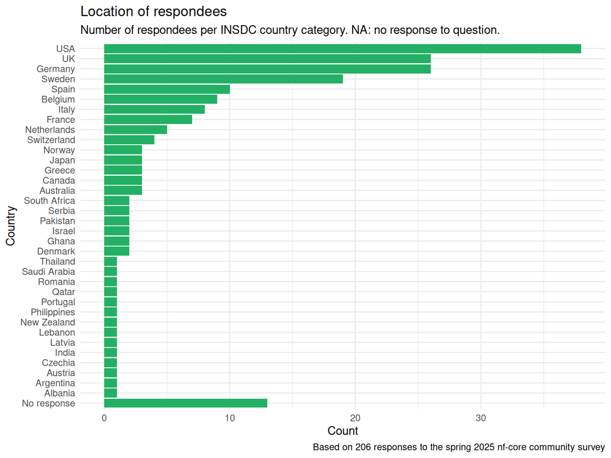

```r
ggplot(
  data_responses_country,
  aes(y = what_country_are_you_based_in, x = nr_response_per_country)
) +
  geom_col(fill = "#24b064") +
  theme_minimal() +
  labs(title = "Location of respondees",
     subtitle = "Number of respondees per INSDC country category. NA: no response to question.",
     x = "Count",
     y = "Country",
     caption = paste("Based on", nr_responses, "responses to the spring 2025 nf-core community survey")
  )
```

To better visualise, we can plot a map with each country that has at least a single response filled with a colour.

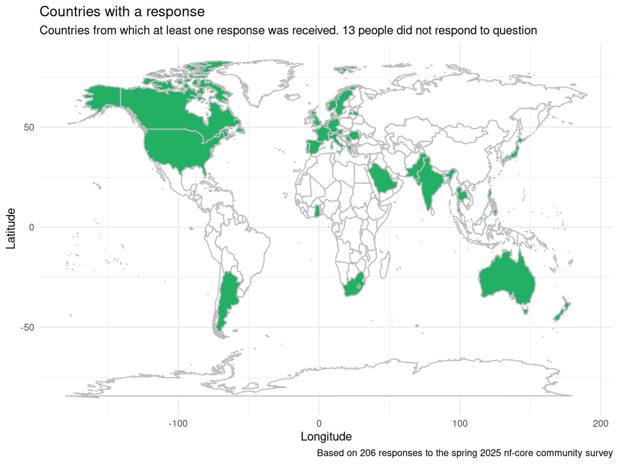

```r
## Merge data with world map
data_map_rendering <- data_map |>
  left_join(data_responses_country |> rename(region = what_country_are_you_based_in)) |>
  mutate(country_fill = ifelse(!is.na(nr_response_per_country), "#24b064", "white"))

# Use scale_fill to set correct colours
ggplot(data_map_rendering,
       aes(long, lat, group = group, fill = country_fill)) +
  geom_polygon(colour = "gray") +
  scale_fill_identity() +
  theme_minimal() +
  labs(title = "Countries with a response",
     subtitle = paste("Countries from which at least one response was received.", nr_country_noresponse ,"people did not respond to question"),
     x = "Longitude",
     y = "Latitude",
     caption = paste("Based on", nr_responses, "responses to the spring 2025 nf-core community survey")
  )
```

### nf-core community member type

We also wanted to understand what type of nf-core community member was responding - a user, developer, or both.

For this we take the raw responses, then clean up the community member type, as we had an ‘other’ column which appears to have been not that useful as most people put in responses that still correspond to our three types. We can summarise this by counting the number of categories in the column.

```r
data_responses_respondertype <- data_responses_raw |>
  select(do_you_consider_yourself_to_be_an_nf_core) |>
  mutate(
    do_you_consider_yourself_to_be_an_nf_core = case_match(
      do_you_consider_yourself_to_be_an_nf_core,
      "Developer, User" ~ "User, Developer",
      "User, Exploring" ~ "User",
      "non nf-core nf dev" ~ "Developer",
      "Newcomer" ~ "User",
      "Newbie" ~ "User",
      "Developer, User, Manager" ~ "User, Developer",
      "Developer, Maintainer" ~ "Developer",
      "develop in nextflow" ~ "Developer",
      "both" ~ "User, Developer",
      NA ~ 'No response',
      .default = do_you_consider_yourself_to_be_an_nf_core
    )
  ) |>
  group_by(do_you_consider_yourself_to_be_an_nf_core) |>
  summarise(nr = n()) |>
  arrange(desc(nr)) |>
  mutate(
    do_you_consider_yourself_to_be_an_nf_core = fct_reorder(do_you_consider_yourself_to_be_an_nf_core, nr),
    do_you_consider_yourself_to_be_an_nf_core = fct_relevel(do_you_consider_yourself_to_be_an_nf_core, 'No response')
  )
```

As with the countries, the best way to plot this is via a bar chart.

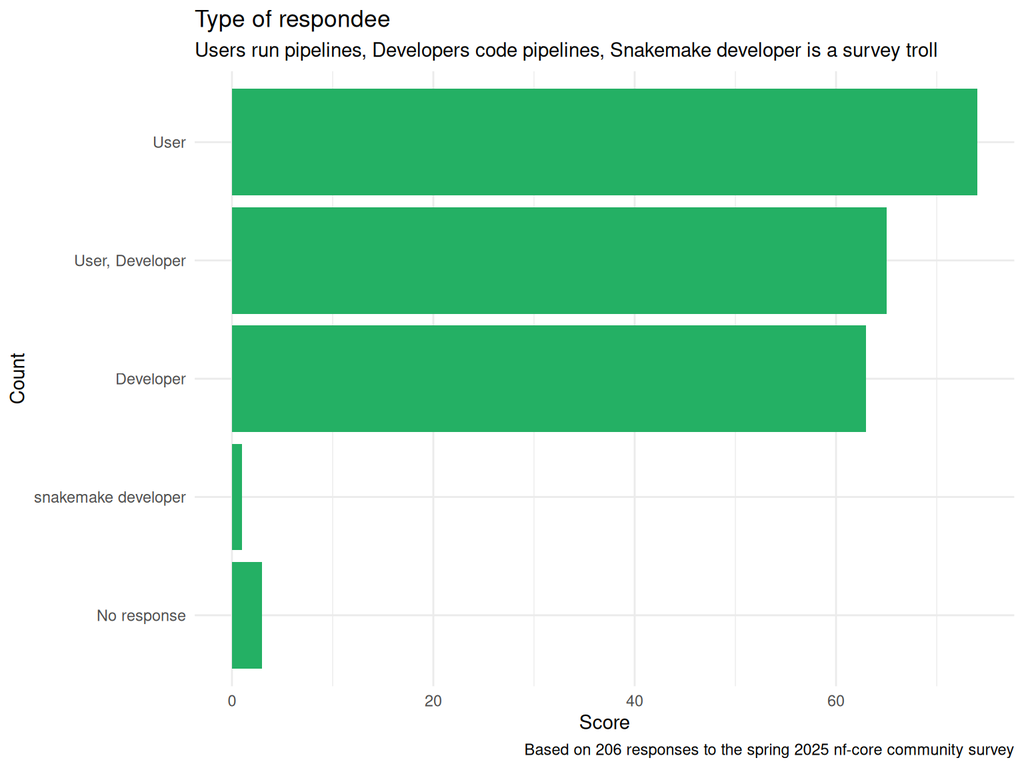

```r
ggplot(
  data_responses_respondertype,
  aes(y = do_you_consider_yourself_to_be_an_nf_core, x = nr)
) +
  geom_col(fill = "#24b064") +
  theme_minimal() +
  labs(title = "Type of respondee",
     subtitle = "Users run pipelines, Developers code pipelines, Snakemake developer is a survey troll",
     x = "Score",
     y = "Count",
     caption = paste("Based on", nr_responses, "responses to the spring 2025 nf-core community survey")
  )
```